# Scaffa_report

# Scaffa ChIP-seq Project read and alignment QC

## Part 1: Raw reads summary table

Initial QC analyses of raw reads was performed in FastQC (V0.11.5)

| **Library** | **# of Raw Reads** | **Sequence Length** | **# of poor quality sequences** | **%GC** |
| --- | --- | --- | --- | --- |
| GroupA_LH20_1 | 68331222 | 150 | 0 | 43 |
| GroupA_LH20_2 | 68331222 | 150 | 0 | 44 |
| GroupA_IgG_1 | 66702588 | 150 | 0 | 43 |
| GroupA_IgG_2 | 66702588 | 150 | 0 | 43 |
| GroupA_HO1_1 | 68697828 | 150 | 0 | 43 |
| GroupA_HO1_2 | 68697828 | 150 | 0 | 43 |
| GroupB_H20_1 | 72639136 | 150 | 0 | 48 |
| GroupB_H20_2 | 72639136 | 150 | 0 | 48 |
| GroupB_IgG_1 | 67845688 | 150 | 0 | 42 |
| GroupB_IgG_2 | 67845688 | 150 | 0 | 42 |
| GroupB_HO1_1 | 63918020 | 150 | 0 | 43 |
| GroupB_HO1_2 | 63918020 | 150 | 0 | 43 |

Note the slightly higher GC content reported for the GroupB_H20_1 and GroupB_H20_2 libraries relative to the other 10. To remove adapters, low-quality sequences, and short sequences, trimming was performed in Trimmomatic (V0.36) using the following parameters:

```
- trimmomatic:
    subcommand: PE
    options:
      "ILLUMINACLIP:/gpfs/data/cbc/cbc_conda_v1/envs/cbc_conda/opt/trimmomatic-0.36/adapters/TruSeq3-PE-2.fa:2:30:5:6:true":
      "SLIDINGWINDOW:10:25 MINLEN:75":
```

## Part 2: Trimmed reads summary table

A second QC analyses of trimmed reads was performed in FastQC (V0.11.5)

| **Library** | **# of Raw Reads** | **Sequence Length** | **# of poor quality sequences** | **%GC** |
| --- | --- | --- | --- | --- |
| GroupA_LH20_1 | 60123899 | 75-150 | 0 | 43 |
| GroupA_LH20_2 | 60123899 | 75-150 | 0 | 43 |
| GroupA_IgG_1 | 55572231 | 75-150 | 0 | 42 |
| GroupA_IgG_2 | 55572231 | 75-150 | 0 | 42 |
| GroupA_HO1_1 | 56866122 | 75-150 | 0 | 42 |
| GroupA_HO1_2 | 56866122 | 75-150 | 0 | 42 |
| GroupB_H20_1 | 61566544 | 75-150 | 0 | 47 |
| GroupB_H20_2 | 61566544 | 75-150 | 0 | 47 |
| GroupB_IgG_1 | 56522411 | 75-150 | 0 | 41 |
| GroupB_IgG_2 | 56522411 | 75-150 | 0 | 41 |
| GroupB_HO1_1 | 53668814 | 75-150 | 0 | 42 |
| GroupB_HO1_2 | 53668814 | 75-150 | 0 | 42 |

## Part 3: Read quality plots

**Library**

**Raw reads**

**Trimmed reads**

GroupA_LH20_1

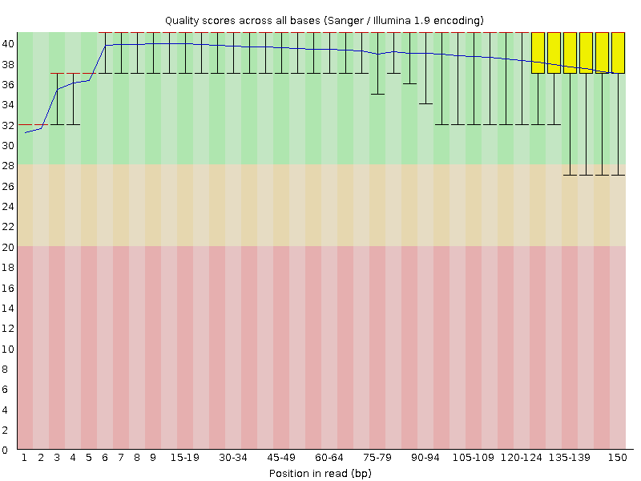

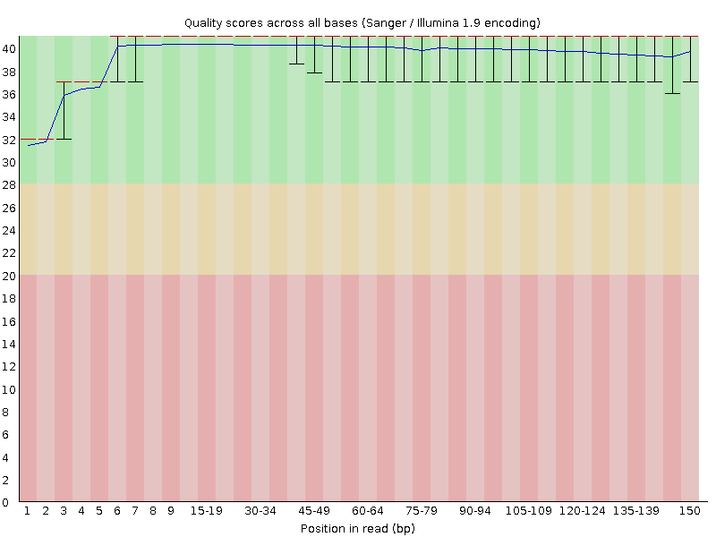

GroupA_LH20_2

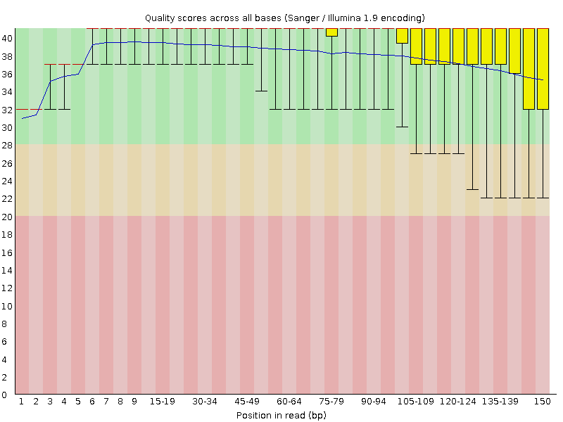

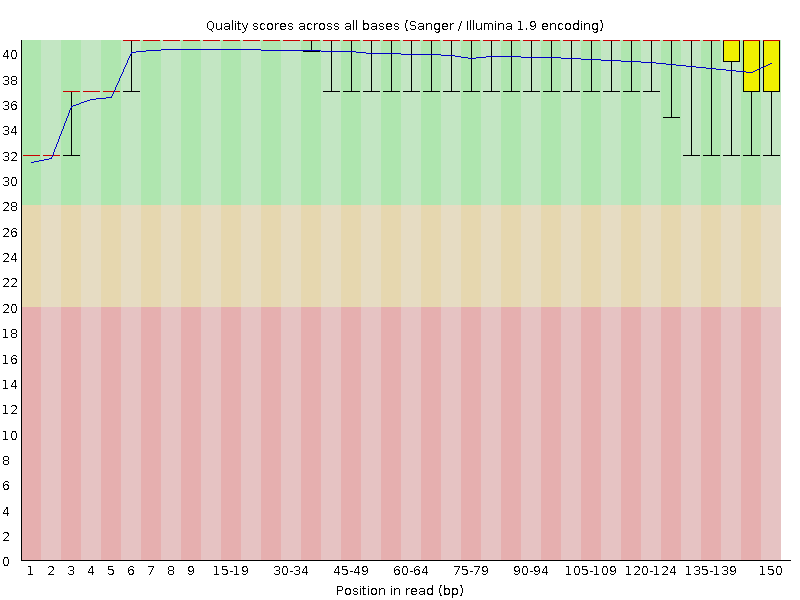

GroupA_IgG_1

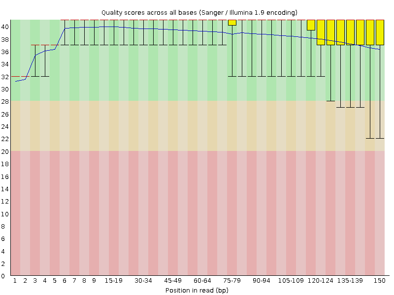

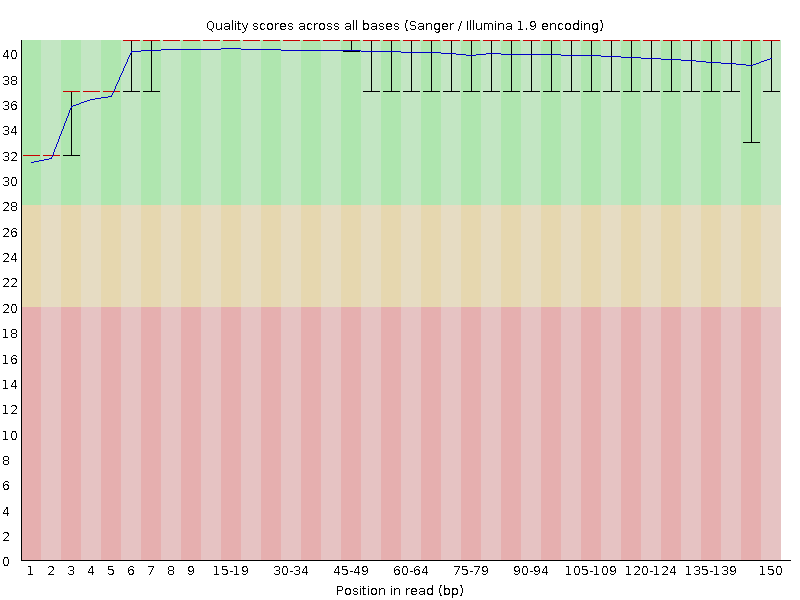

GroupA_IgG_2

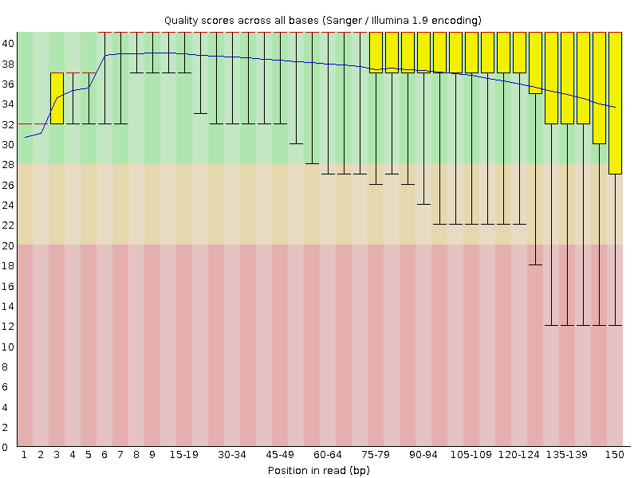

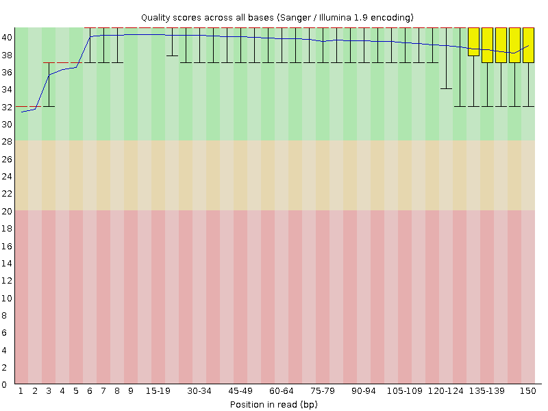

GroupA_HO1_1

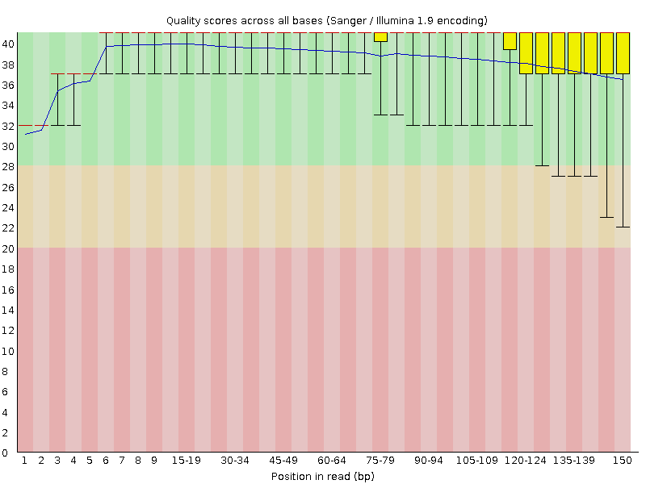

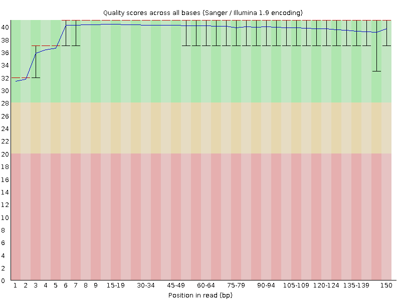

GroupA_HO1_2

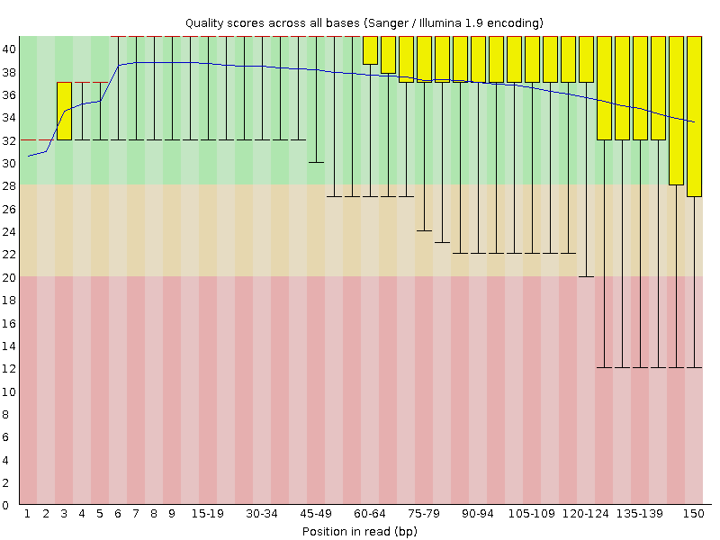

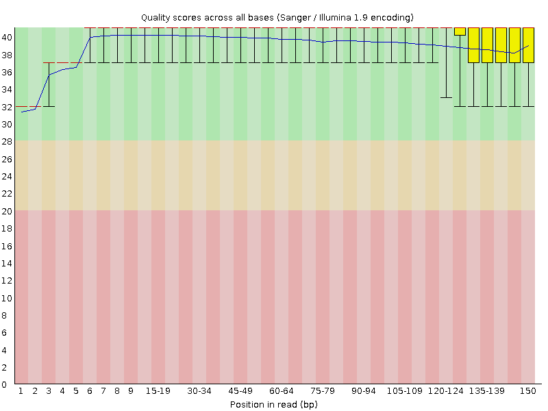

GroupB_H20_1

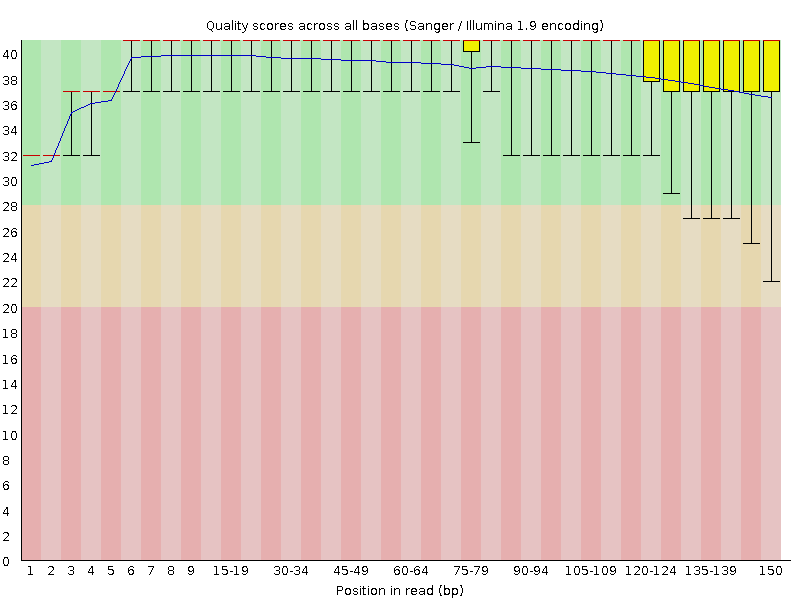

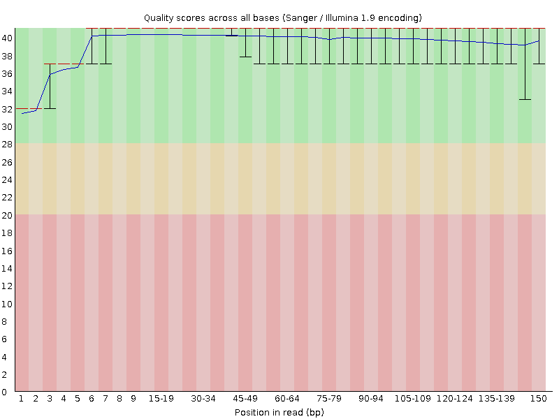

GroupB_H20_2

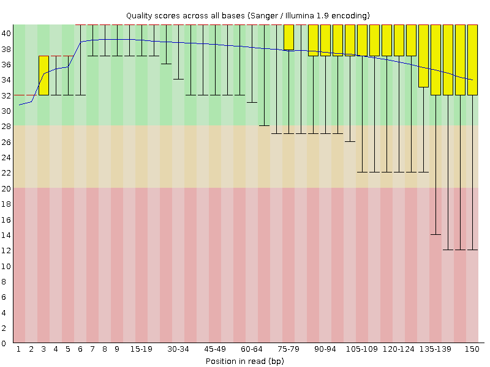

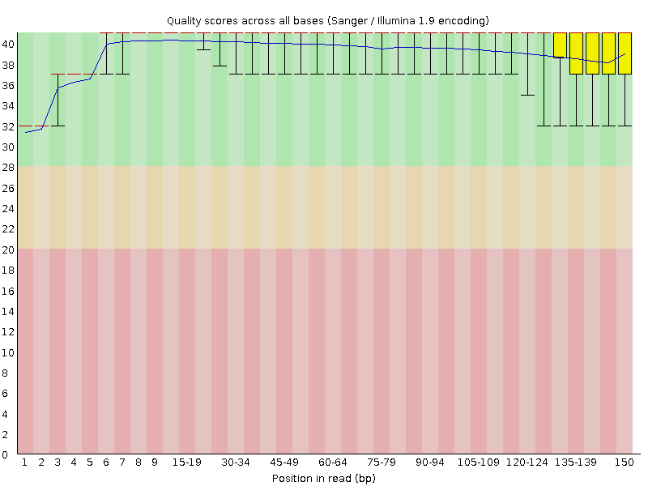

GroupB_IgG_1

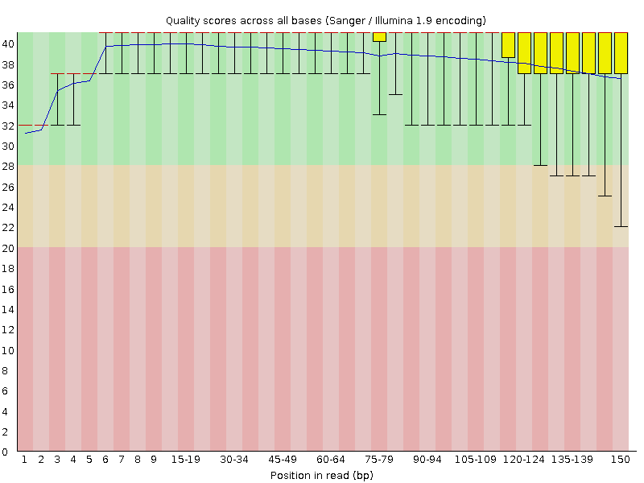

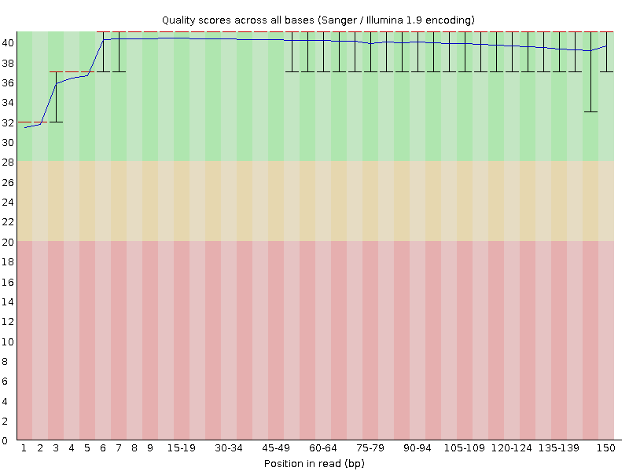

GroupB_IgG_2

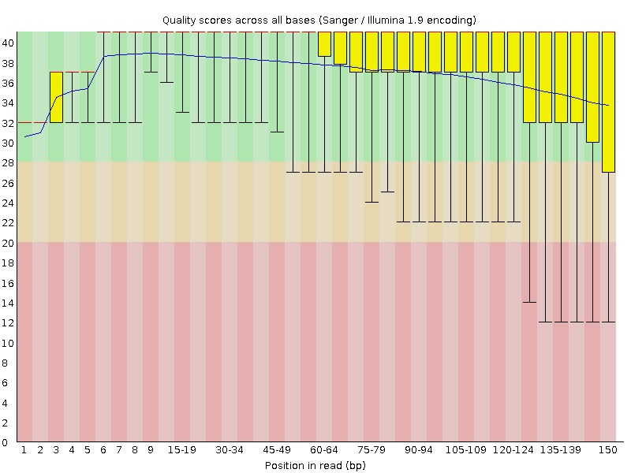

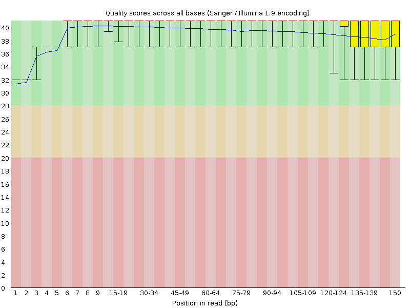

GroupB_HO1_1

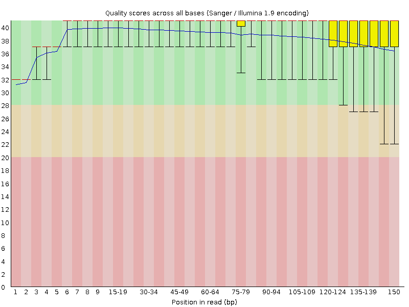

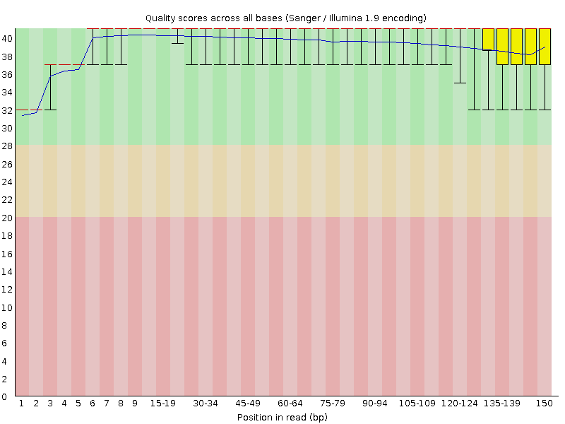

GroupB_HO1_2

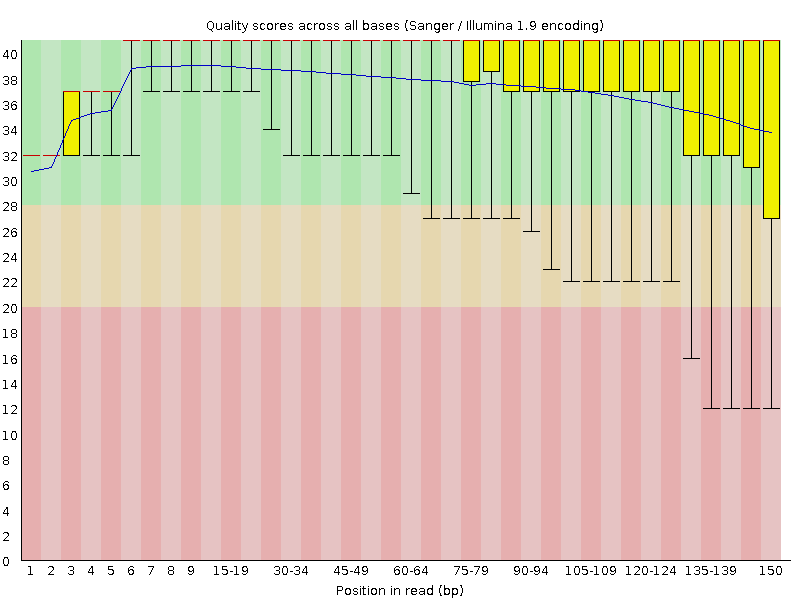

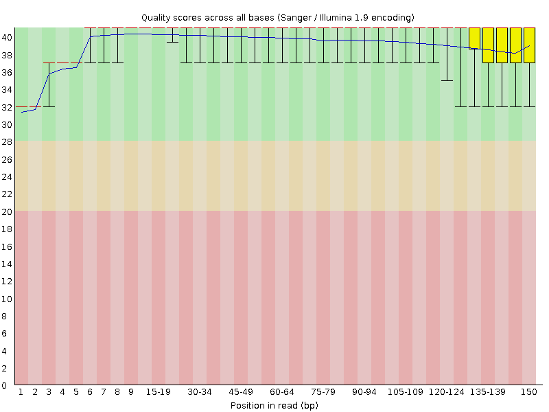

## Part 4: GC content plots

**Library**

**Raw reads**

**Trimmed reads**

GroupA_LH20_1

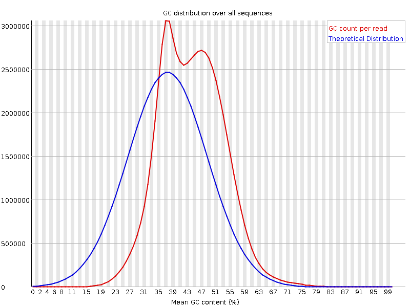

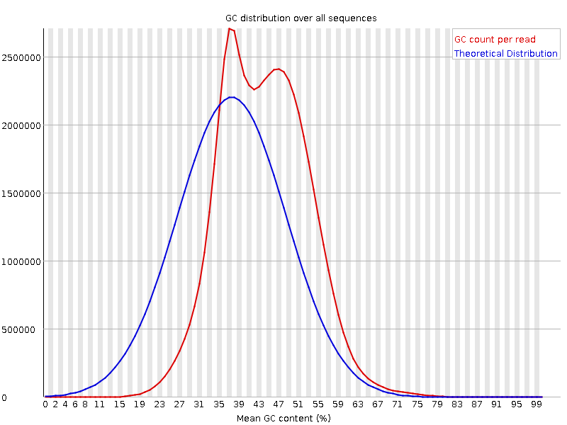

GroupA_LH20_2

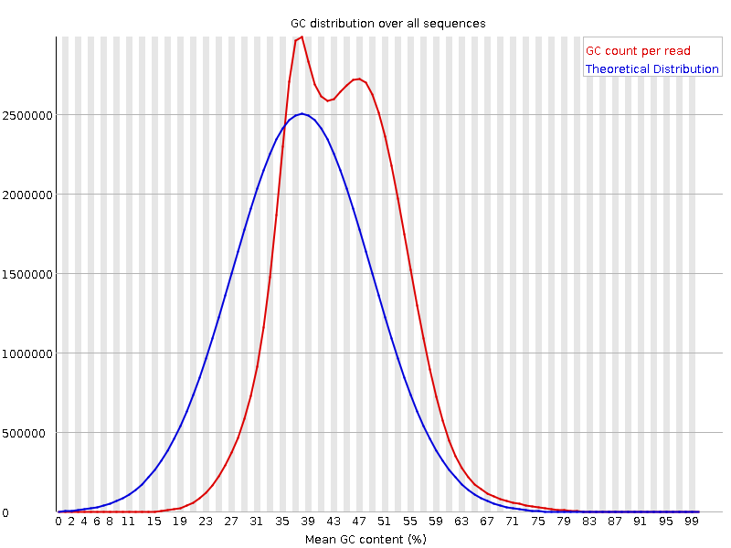

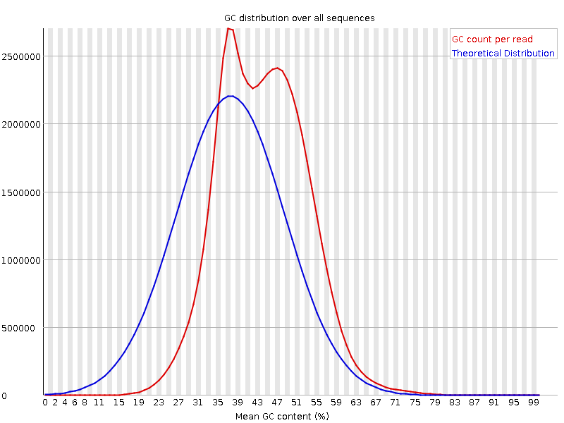

GroupA_IgG_1

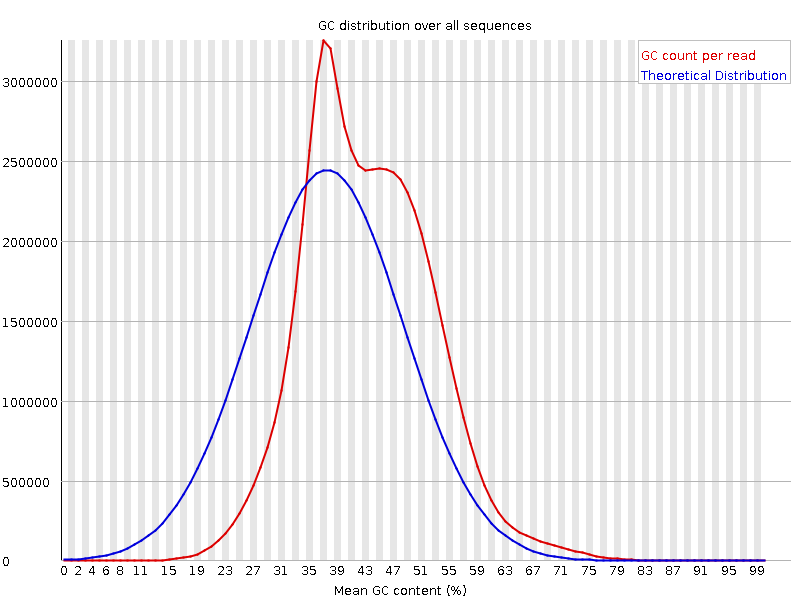